# Model VECM

Wiktoria Szczypka

20 stycznia 2020

### Wstęp

Celem tego projektu jest zbudowanie modelu VECM dla indeksów giełdowych z poszczególnych krajów:

- Polska - WIG,
- Wielka Brytania - FTSE,
- Stany Zjednoczone - SPX,
- Chiny - SHC,
- Singapur - STI.

Za pomocą tego modelu możliwe będzie zbadanie impulsów między giełdami.

Zaczynam od wczytania danych - są to indeksy zamknięcia wraz z datami dla powyższych krajów.

```r
setwd("C:/Users/Wiktoria/Documents/IiE/Rok 4/AW/Projekt 2")


shc <- read.csv("shc_d.csv")[,c(1,5)]
spx <- read.csv("spx_d.csv")[,c(1,5)]
sti <- read.csv("sti_d.csv")[,c(1,5)]
wig <- read.csv("wig_d.csv")[,c(1,5)]
ftse <- read.csv("ftse.csv")[,c(1,5)]
```

Za pomocą funkcji ‘full_join’ łącze dane w zbiór. Moje dane różnią się - dla niektórych dat obserwacje nie pokrywają się. Funkcja ta stworzy zbiór z wartościami brakującymi (NA), gdy zmienna dla danej daty nie ma takiej obserwacji.

```r
library(dplyr)

dane <- full_join(shc,spx, by="Data")
dane <- full_join(dane,sti, by="Data")
dane <- full_join(dane,ftse, by="Data")
dane <- full_join(dane,wig, by="Data")
colnames(dane) <- c("Data", "shc", "spx", "sti","ftse", "wig")


dane <- dane[order(dane$Data),]
```

W celu uzupełnienia wartości NA w zbiorze danych używam interpolacji liniowej. Umożliwia to funkcja ‘na.approx’.

```r
library(zoo)
dane[,2:6] <- lapply(dane[,-1], na.approx)
```

Następnie obliczam logarytmy cen dla zmiennych. Wprowadzam jednak modyfikacje - z powodów różnic w strefach czasowych ‘przesuwam’ zmienne SHC i STI o 1 dzień do przodu, aby lepiej obrazowały one rzeczywistość - w tych krajach przesunięcie czasowe jest o 7 godzin naprzód względem Polski.

```r
#logarytm ceny, dla chin i singapuru przesuwam o jedna obserwacje
log_ceny <- data.frame(SHC=double(), SPX=double(), STI=double(),FTSE=double(), WIG=double())
for(i in 1:2584) {
  log_ceny[i,1] <- log(dane[i+1,2])
  log_ceny[i,2] <- log(dane[i,3])
  log_ceny[i,3] <- log(dane[i+1,4])
  log_ceny[i,4] <- log(dane[i,5])
  log_ceny[i,5] <- log(dane[i,6])
}
```

### Model VECM

Model VECM to odpowiednik modelu VAR w warunkach kointegracji szeregów czasowych. Skointegrowanie szeregów czasowych oznacza istnienie wspólnej długookresowej ścieżki równowagi dla tych szeregów. W praktyce kointegracja występuje, gdy szeregi czasowe nie są stacjonarne (najczęściej są zintegrowane w stopniu pierwszym) oraz istnieje ich stacjonarna kombinacja liniowa. W badaniach zjawiska kointegracji stosuje się najczęściej test śladu lub test maksymalnej wartości własnej.

Pożądana jest stacjonarność pierwszego rzędu. Poniżej przeprowadzono test ADF dla logarytmów cen.

```r
library(tseries)
lapply(log_ceny, adf.test)
```

```
## $SHC
##
##  Augmented Dickey-Fuller Test
##
## data:  X[[i]]
## Dickey-Fuller = -2.5497, Lag order = 13, p-value = 0.3456
## alternative hypothesis: stationary
##
##
## $SPX
##
##  Augmented Dickey-Fuller Test
##
## data:  X[[i]]
## Dickey-Fuller = -3.5516, Lag order = 13, p-value = 0.03731
## alternative hypothesis: stationary
##
##
## $STI
##
##  Augmented Dickey-Fuller Test
##
## data:  X[[i]]
## Dickey-Fuller = -3.3861, Lag order = 13, p-value = 0.05581
## alternative hypothesis: stationary
##
##
## $FTSE
##
##  Augmented Dickey-Fuller Test
##
## data:  X[[i]]
## Dickey-Fuller = -3.6462, Lag order = 13, p-value = 0.02821
## alternative hypothesis: stationary
##
##
## $WIG
##
##  Augmented Dickey-Fuller Test
##
## data:  X[[i]]
## Dickey-Fuller = -2.7272, Lag order = 13, p-value = 0.2704
## alternative hypothesis: stationary
```

Odrzucono hipotezę zerową (szereg nie jest stacjonarny) na poziomie istotności 5% dla zmiennej SPX oraz FTSE. Pozostałe szeregi są niestacjonarne.

Ze względu na to, że pożądana jest przez nas stacjonarność pierwszego rzędu wykonuje ponownie test ADF dla pierwszych różnic.

```r
log_ceny_roz <- data.frame(SHC=double(), SPX=double(), STI=double(),FTSE=double(), WIG=double())
for(i in 1:2583) {
  log_ceny_roz[i,1] <- log_ceny[i+1,1] - log_ceny[i, 1]
  log_ceny_roz[i,2] <- log_ceny[i+1,2] - log_ceny[i, 2]
  log_ceny_roz[i,3] <- log_ceny[i+1,3] - log_ceny[i, 3]
  log_ceny_roz[i,4] <- log_ceny[i+1,4] - log_ceny[i, 4]
  log_ceny_roz[i,5] <- log_ceny[i+1,5] - log_ceny[i, 5]
}

lapply(log_ceny_roz, adf.test)
```

```
## $SHC
##
##  Augmented Dickey-Fuller Test
##
## data:  X[[i]]
## Dickey-Fuller = -12.594, Lag order = 13, p-value = 0.01
## alternative hypothesis: stationary
##
##
## $SPX
##
##  Augmented Dickey-Fuller Test
##
## data:  X[[i]]
## Dickey-Fuller = -14.54, Lag order = 13, p-value = 0.01
## alternative hypothesis: stationary
##
##
## $STI
##
##  Augmented Dickey-Fuller Test
##
## data:  X[[i]]
## Dickey-Fuller = -13.369, Lag order = 13, p-value = 0.01
## alternative hypothesis: stationary
##
##
## $FTSE
##
##  Augmented Dickey-Fuller Test
##
## data:  X[[i]]
## Dickey-Fuller = -15.248, Lag order = 13, p-value = 0.01
## alternative hypothesis: stationary
##
##
## $WIG
##
##  Augmented Dickey-Fuller Test
##
## data:  X[[i]]
## Dickey-Fuller = -13.632, Lag order = 13, p-value = 0.01
## alternative hypothesis: stationary
```

Tym razem dla wszystkich zmiennych odrzucono hipotezę zerową - oznacza to, że szeregi czasowe są stacjonarne. Zatem spełnione jest założenie, że zmienne są I(0) lub I(1).

Następnie należy wykonać testy Johansena badające liczbę relacji kointegrujących. Wykonany został poniżej zarówno test śladu jak i maksymalnej wartości własnej. Parametrem testu jest opóźnienie, jest ono o 1 mniejsze niż to co uzyskano za pomocą funkcji `VARselect`.

```r
library(vars)
VARselect(log_ceny)
```

```
## $selection
## AIC(n)  HQ(n)  SC(n) FPE(n)
##      3      2      2      3
##
## $criteria
##                    1             2             3             4             5
## AIC(n) -4.787964e+01 -4.818543e+01 -4.819187e+01 -4.818986e+01 -4.818430e+01
## HQ(n)  -4.785491e+01 -4.814009e+01 -4.812593e+01 -4.810330e+01 -4.807714e+01
## SC(n)  -4.781142e+01 -4.806036e+01 -4.800996e+01 -4.795109e+01 -4.788869e+01
## FPE(n)  1.607451e-21  1.183950e-21  1.176348e-21  1.178720e-21  1.185288e-21
##                    6             7             8             9            10
## AIC(n) -4.818149e+01 -4.817691e+01 -4.817643e+01 -4.816723e+01 -4.816557e+01
## HQ(n)  -4.805372e+01 -4.802853e+01 -4.800744e+01 -4.797763e+01 -4.795537e+01
## SC(n)  -4.782903e+01 -4.776759e+01 -4.771027e+01 -4.764421e+01 -4.758571e+01
## FPE(n)  1.188630e-21  1.194092e-21  1.194668e-21  1.205720e-21  1.207729e-21
```

Otrzymano wyniki 3 i 2, więc jako opóźnienie w teście Johansena przyjęto 2.

```r
jottest <- ca.jo(log_ceny, type = "trace",K=2, ecdet="none", spec="longrun")
summary(jottest)
```

```
##
## ######################
## # Johansen-Procedure #
## ######################
##
## Test type: trace statistic , with linear trend
##
## Eigenvalues (lambda):
## [1] 0.0163435527 0.0084003551 0.0054919852 0.0023347015 0.0000764841
##
## Values of teststatistic and critical values of test:
##
##           test 10pct  5pct  1pct
## r <= 4 |  0.20  6.50  8.18 11.65
## r <= 3 |  6.23 15.66 17.95 23.52
## r <= 2 | 20.45 28.71 31.52 37.22
## r <= 1 | 42.23 45.23 48.28 55.43
## r = 0  | 84.78 66.49 70.60 78.87
##
## Eigenvectors, normalised to first column:
## (These are the cointegration relations)
##
##            SHC.l2    SPX.l2    STI.l2    FTSE.l2    WIG.l2
## SHC.l2   1.000000  1.000000  1.000000  1.0000000  1.000000
## SPX.l2  -8.283101  2.169572  0.745482 -0.5867519  7.812217
## STI.l2  -5.926262  9.386058 -4.552785 -0.7415951 -6.926604
## FTSE.l2 35.832995 -2.338567  4.969350  0.1504698 -0.992186
## WIG.l2  -7.237909 -6.315566 -7.117219  0.8494838 -3.565946
##
## Weights W:
## (This is the loading matrix)
##
##               SHC.l2        SPX.l2        STI.l2       FTSE.l2        WIG.l2
## SHC.d   5.150471e-05 -0.0002734232 -0.0006355363 -0.0030377875  2.864001e-06
## SPX.d  -6.478501e-05 -0.0001296208  0.0001065098 -0.0006916828 -3.884692e-05
## STI.d  -9.527561e-05 -0.0013321027  0.0002615799 -0.0008963346 -7.383099e-06
## FTSE.d -6.687893e-04  0.0002510034  0.0003186054 -0.0009396062 -2.554397e-05
## WIG.d   2.714495e-04  0.0005810267  0.0007165382 -0.0010880190 -8.361507e-06
```

```r
jotest<-ca.jo(log_ceny,type="eigen",K = 2,ecdet = "none",spec = "longrun")
summary(jotest)
```

```
##
## ######################
## # Johansen-Procedure #
## ######################
##
## Test type: maximal eigenvalue statistic (lambda max) , with linear trend
##
## Eigenvalues (lambda):
## [1] 0.0163435527 0.0084003551 0.0054919852 0.0023347015 0.0000764841
##
## Values of teststatistic and critical values of test:
##
##           test 10pct  5pct  1pct
## r <= 4 |  0.20  6.50  8.18 11.65
## r <= 3 |  6.04 12.91 14.90 19.19
## r <= 2 | 14.22 18.90 21.07 25.75
## r <= 1 | 21.78 24.78 27.14 32.14
## r = 0  | 42.55 30.84 33.32 38.78
##
## Eigenvectors, normalised to first column:
## (These are the cointegration relations)
##
##            SHC.l2    SPX.l2    STI.l2    FTSE.l2    WIG.l2
## SHC.l2   1.000000  1.000000  1.000000  1.0000000  1.000000
## SPX.l2  -8.283101  2.169572  0.745482 -0.5867519  7.812217
## STI.l2  -5.926262  9.386058 -4.552785 -0.7415951 -6.926604
## FTSE.l2 35.832995 -2.338567  4.969350  0.1504698 -0.992186
## WIG.l2  -7.237909 -6.315566 -7.117219  0.8494838 -3.565946
##
## Weights W:
## (This is the loading matrix)
##
##               SHC.l2        SPX.l2        STI.l2       FTSE.l2        WIG.l2
## SHC.d   5.150471e-05 -0.0002734232 -0.0006355363 -0.0030377875  2.864001e-06
## SPX.d  -6.478501e-05 -0.0001296208  0.0001065098 -0.0006916828 -3.884692e-05
## STI.d  -9.527561e-05 -0.0013321027  0.0002615799 -0.0008963346 -7.383099e-06
## FTSE.d -6.687893e-04  0.0002510034  0.0003186054 -0.0009396062 -2.554397e-05
## WIG.d   2.714495e-04  0.0005810267  0.0007165382 -0.0010880190 -8.361507e-06
```

Oba testy wskazały na to, że liczba relacji kointegrujących to 1.

Poniżej stworzono model VECM dla opóźnienia 2 i liczby relacji 1.

```r
library(tsDyn)
model_VECM<-VECM(log_ceny, lag = 2, r=1, estim = "ML")
summary(model_VECM)
```

```
## #############
## ###Model VECM
## #############
## Full sample size: 2584   End sample size: 2581
## Number of variables: 5   Number of estimated slope parameters 60
## AIC -124388.7    BIC -124013.9   SSR 1.170645
## Cointegrating vector (estimated by ML):
##    SHC       SPX       STI     FTSE       WIG
## r1   1 -7.406375 -4.773437 32.33173 -6.860053
##
##
##               ECT                  Intercept           SHC -1
## Equation SHC   1.9e-05(0.0003)     -0.0024(0.0319)     0.0247(0.0210)
## Equation SPX  -7.4e-05(0.0002)     0.0096(0.0212)      0.0408(0.0139)**
## Equation STI  -0.0002(0.0002)      0.0191(0.0185)      -0.0253(0.0121)*
## Equation FTSE -0.0007(0.0002)***   0.0905(0.0224)***   0.0588(0.0147)***
## Equation WIG  0.0003(0.0002).      -0.0385(0.0209).    0.0465(0.0137)***
##               SPX -1             STI -1             FTSE -1
## Equation SHC  0.0055(0.0456)     0.0753(0.0394).    0.0250(0.0425)
## Equation SPX  -0.1735(0.0303)*** 0.3916(0.0262)***  -0.0181(0.0282)
## Equation STI  0.0329(0.0264)     0.0356(0.0228)     0.0315(0.0246)
## Equation FTSE -0.0793(0.0320)*   0.5106(0.0277)***  -0.1427(0.0298)***
## Equation WIG  0.0722(0.0299)*    0.4948(0.0259)***  -0.0344(0.0278)
##               WIG -1              SHC -2              SPX -2
## Equation SHC  -0.0348(0.0332)     -0.0376(0.0211).    -0.0265(0.0458)
## Equation SPX  -0.0034(0.0221)     0.0143(0.0140)      -0.0948(0.0304)**
## Equation STI  -0.0178(0.0192)     -0.0124(0.0122)     -0.0197(0.0265)
## Equation FTSE 0.0006(0.0233)      0.0112(0.0148)      -0.0053(0.0321)
## Equation WIG  -0.0472(0.0218)*    0.0098(0.0138)      0.0380(0.0300)
##               STI -2              FTSE -2             WIG -2
## Equation SHC  0.0322(0.0427)      0.0724(0.0417).     -0.0104(0.0311)
## Equation SPX  0.0566(0.0284)*     0.0895(0.0277)**    -0.0412(0.0207)*
## Equation STI  -0.0119(0.0247)     0.0869(0.0241)***   -0.0451(0.0180)*
## Equation FTSE 0.0384(0.0300)      0.0184(0.0293)      -0.0368(0.0219).
## Equation WIG  0.0531(0.0280).     -0.0002(0.0273)     -0.0730(0.0204)***
```

Wykonay zostanie teraz wielowymiarowy test badający czy występuje autokorelacja. Hipoteza zerowa: brak autokorelacji. Do testu zostanie użyty model VAR stworzony dla reszt z modelu VAR dla logarytmów cen.

Jako opóźnienie w pierwszym modelu VAR przyjęto 3.

```r
modelVAR3 <- VAR(log_ceny, p=3)

reszty3 <- data.frame(SHC = modelVAR3$varresult$SHC$residuals,
                      SPX = modelVAR3$varresult$SPX$residuals,
                      STI = modelVAR3$varresult$STI$residuals,
                      FTSE = modelVAR3$varresult$FTSE$residuals,
                      WIG = modelVAR3$varresult$WIG$residuals

)
```

Następnie stoworzono model VAR dla reszt z opóźnieniem 1.

```r
VARselect(reszty3)
```

```
## $selection
## AIC(n)  HQ(n)  SC(n) FPE(n)
##      1      1      1      1
##
## $criteria
##                    1             2             3             4             5
## AIC(n) -4.823076e+01 -4.821263e+01 -4.820577e+01 -4.819988e+01 -4.819877e+01
## HQ(n)  -4.820601e+01 -4.816725e+01 -4.813975e+01 -4.811324e+01 -4.809149e+01
## SC(n)  -4.816248e+01 -4.808744e+01 -4.802368e+01 -4.796088e+01 -4.790286e+01
## FPE(n)  1.131479e-21  1.152177e-21  1.160114e-21  1.166964e-21  1.168268e-21
##                    6             7             8             9            10
## AIC(n) -4.819222e+01 -4.819318e+01 -4.818589e+01 -4.817949e+01 -4.817403e+01
## HQ(n)  -4.806431e+01 -4.804465e+01 -4.801673e+01 -4.798969e+01 -4.796360e+01
## SC(n)  -4.783941e+01 -4.778347e+01 -4.771927e+01 -4.765597e+01 -4.759360e+01
## FPE(n)  1.175951e-21  1.174823e-21  1.183423e-21  1.191031e-21  1.197562e-21
```

```r
modelVAR3_reszty <- VAR(reszty3, p=1)
```

Poniżej wykonano wielowymiarowy test za pomocą funkcji `serial.test`.

```r
serial.test(modelVAR3_reszty, type = "BG")
```

```
##
##  Breusch-Godfrey LM test
##
## data:  Residuals of VAR object modelVAR3_reszty
## Chi-squared = 132.36, df = 125, p-value = 0.309
```

Jak widać wartość p jest duża, co oznacza brak powodów do odrzucenia hipotezy zerowej - brak autokorelacji.

Kolejnym krokiem jest zbadanie impulsów - czyli jak impuls na jednej giełdzie wpłynie na drugą. Kolejność zmiennych w modelu ma znaczenie - można interpretować wyniki tylko ‘wprzód’. Giełda polska została umieszczona na samym końcu, aby zbadać jak impulsy pozostałych giełd na nią wpływają.

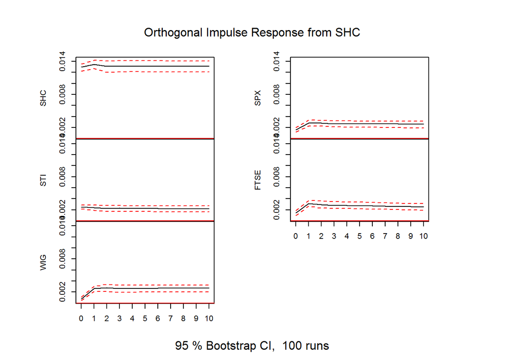

```r
plot(irf(model_VECM, impulse = "SHC"))
```

Impuls na giełdzie chińskiej najmniej wpływa na giełde w Singapurze. Najbardziej gwałtowny wpływ można zauważyć na giełdę londyńską. Na giełdzie polskiej wpływ ten bardzo długo się utrzymuje.

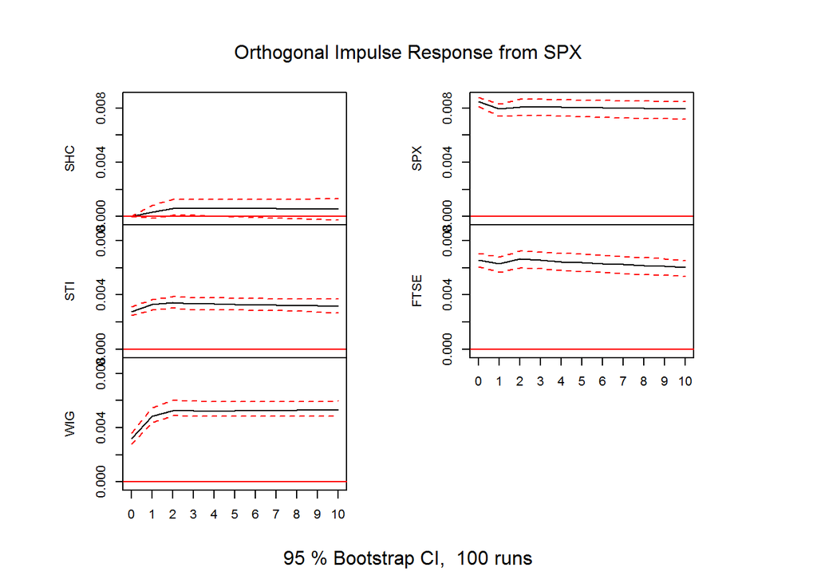

```r
plot(irf(model_VECM, impulse = "SPX"))
```

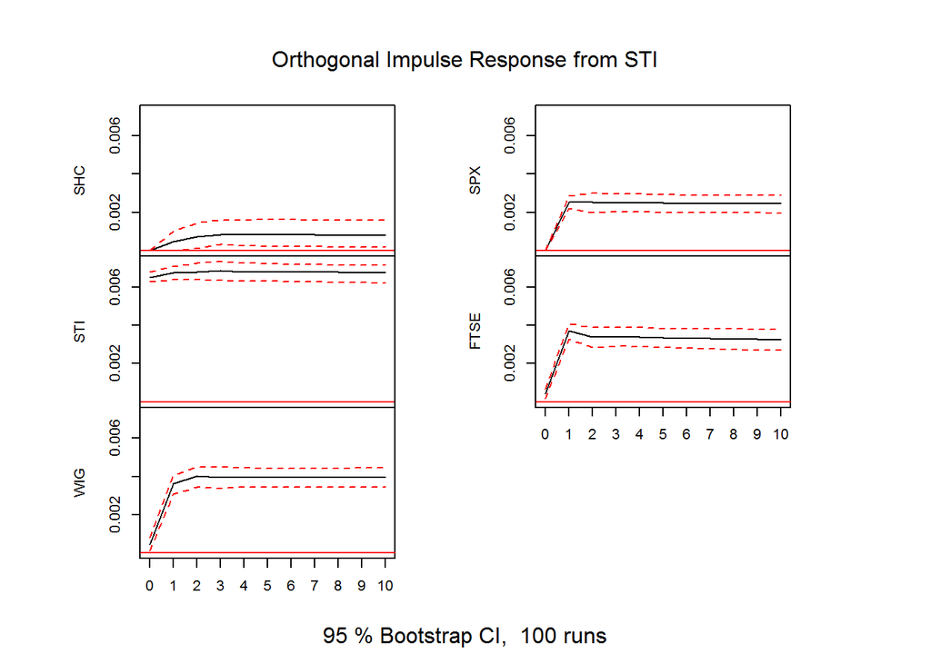

```r
plot(irf(model_VECM, impulse = "STI"))
```

Impuls na giełdzie singapurskiej ma bardzo duży wpływ na giełdę londyńską i polską zarówno krótko jak i długoterminowo.

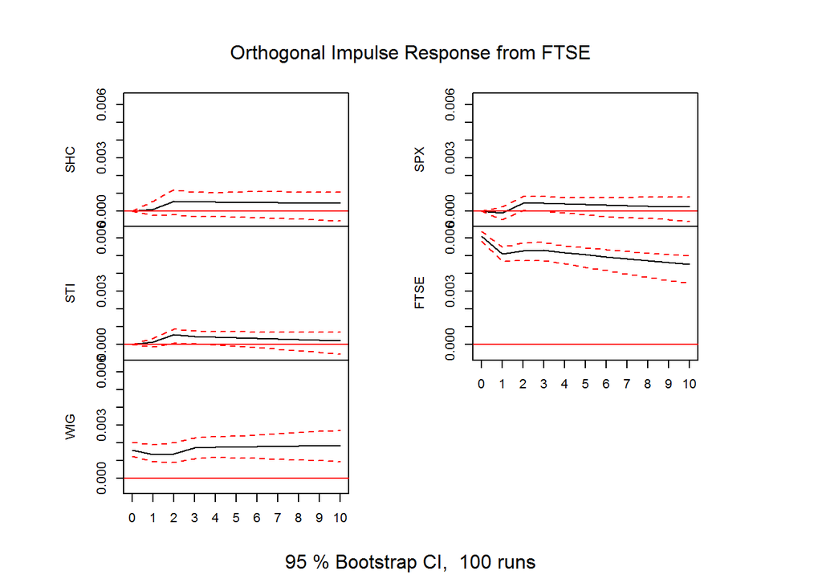

```r
plot(irf(model_VECM, impulse = "FTSE"))
```

Impuls na giełdzie londyńskiej nie ma dużego wpływu na giełdę polską.